# Latihan K2

Rafi Adabhi Sunarya

2025-08-29

# Library

```r
library(dplyr)
library(TTR)
library(forecast)
library(lmtest) #digunakan untuk uji formal pendeteksian autokorelasi
library(orcutt) #untuk membuat model regresi Cochrane-Orcutt
library(HoRM) #untuk membuat model regresi Hildreth-Lu
```

# Input Data

Data yang digunakan dalam kesempatan kali ini adalah data IPM Kabupaten Subang periode tahun 2010-2024.

```r
# Membuat vektor tahun dari 2010 sampai 2024
tahun <- c(2010, 2011, 2012, 2013, 2014, 2015,
           2016, 2017, 2018, 2019, 2020, 2021,
           2022, 2023, 2024)

# Membuat vektor nilai IPM yang sesuai dengan tahun di atas
ipm <- c(63.54, 64.21, 64.86, 65.48, 65.80, 66.52,
         67.14, 67.73, 68.31, 68.69, 68.95, 69.13,
         69.87, 70.70, 71.36)

# Menggabungkan kedua vektor (tahun dan ipm) menjadi sebuah matriks
datas <- cbind(tahun, ipm)

# Mengubah format matriks menjadi data frame agar lebih mudah dianalisis
datas <- as.data.frame(datas)

# Menampilkan isi data frame
datas
```

```
##    tahun   ipm
## 1   2010 63.54
## 2   2011 64.21
## 3   2012 64.86
## 4   2013 65.48
## 5   2014 65.80
## 6   2015 66.52
## 7   2016 67.14
## 8   2017 67.73
## 9   2018 68.31
## 10  2019 68.69
## 11  2020 68.95
## 12  2021 69.13
## 13  2022 69.87
## 14  2023 70.70
## 15  2024 71.36
```

# Eksplorasi Data

Sebelum melakukan regresi, akan diperlihatkan *plot time-series* dari IPM Kabupaten Subang Periode 2010-2024

```r
#Membentuk objek time series
data.ts<-ts(datas$ipm)
data.ts
```

```
## Time Series:
## Start = 1
## End = 15
## Frequency = 1
##  [1] 63.54 64.21 64.86 65.48 65.80 66.52 67.14 67.73 68.31 68.69 68.95 69.13
## [13] 69.87 70.70 71.36
```

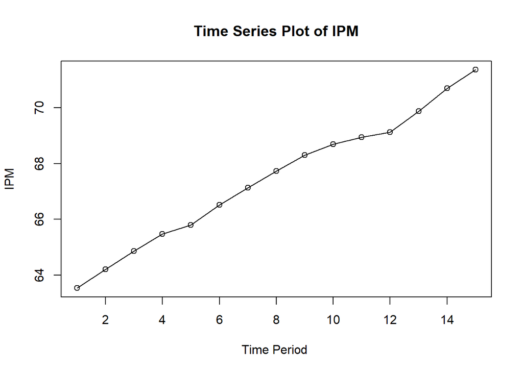

```r
#Membuat plot time series
ts.plot(data.ts, xlab="Time Period ", ylab="IPM", main= "Time Series Plot of IPM")
points(data.ts)
```

```r
# Metode Double Moving Average (DMA) dengan periode 3

# 1. Hitung Simple Moving Average (SMA) dengan periode 3
dt.sma <- SMA(data.ts, n = 3)   # setiap nilai = rata-rata 3 observasi terakhir

# 2. Hitung Double Moving Average (DMA) = SMA dari hasil SMA pertama
dma <- SMA(dt.sma, n = 3)

# 3. Hitung komponen level (At)
At <- 2 * dt.sma - dma          # At = 2*SMA - DMA

# 4. Hitung komponen slope/trend (Bt)
Bt <- 2/(3 - 1) * (dt.sma - dma) # Bt = (2/(n-1)) * (SMA - DMA), dengan n=3

# 5. Hitung fitted values (ramalan historis)
dt.dma <- At + Bt               # Yhat_t = At + Bt

# 6. Sesuaikan panjang vektor dengan data asli (tambahkan NA di awal)
dt.ramal <- c(NA, dt.dma)

# 7. Buat horizon ramalan ke depan (contoh: 5 langkah)
t <- 1:5
f <- c()

# 8. Hitung ramalan ke depan (out-of-sample forecast)
# Rumus: F_{t+m} = A_t + B_t * m
for (i in t) {
  f[i] <- At[length(At)] + Bt[length(Bt)] * i
}
```

```r
dt.gab <- cbind(
  aktual      = c(data.ts,  rep(NA, 5)),   # data asli (time series) + NA agar panjang sama
  pemulusan1  = c(dt.sma,   rep(NA, 5)),   # hasil SMA (pemulusan pertama) + NA
  pemulusan2  = c(dt.dma,   rep(NA, 5)),   # hasil DMA (pemulusan kedua) + NA
  At          = c(At,       rep(NA, 5)),   # komponen level + NA
  Bt          = c(Bt,       rep(NA, 5)),   # komponen trend + NA
  ramalan     = c(dt.ramal, f[-1])         # fitted values + ramalan ke depan
)

dt.gab
```

```
##       aktual pemulusan1 pemulusan2       At        Bt  ramalan
##  [1,]  63.54         NA         NA       NA        NA       NA
##  [2,]  64.21         NA         NA       NA        NA       NA
##  [3,]  64.86   64.20333         NA       NA        NA       NA
##  [4,]  65.48   64.85000         NA       NA        NA       NA
##  [5,]  65.80   65.38000   66.51778 65.94889 0.5688889       NA
##  [6,]  66.52   65.93333   67.02444 66.47889 0.5455556 66.51778
##  [7,]  67.14   66.48667   67.59333 67.04000 0.5533333 67.02444
##  [8,]  67.73   67.13000   68.35667 67.74333 0.6133333 67.59333
##  [9,]  68.31   67.72667   68.95111 68.33889 0.6122222 68.35667
## [10,]  68.69   68.24333   69.33000 68.78667 0.5433333 68.95111
## [11,]  68.95   68.65000   69.53667 69.09333 0.4433333 69.33000
## [12,]  69.13   68.92333   69.55889 69.24111 0.3177778 69.53667
## [13,]  69.87   69.31667   70.02333 69.67000 0.3533333 69.55889
## [14,]  70.70   69.90000   70.94000 70.42000 0.5200000 70.02333
## [15,]  71.36   70.64333   72.02333 71.33333 0.6900000 70.94000
## [16,]     NA         NA         NA       NA        NA 72.02333
## [17,]     NA         NA         NA       NA        NA 72.71333
## [18,]     NA         NA         NA       NA        NA 73.40333
## [19,]     NA         NA         NA       NA        NA 74.09333
## [20,]     NA         NA         NA       NA        NA 74.78333
```

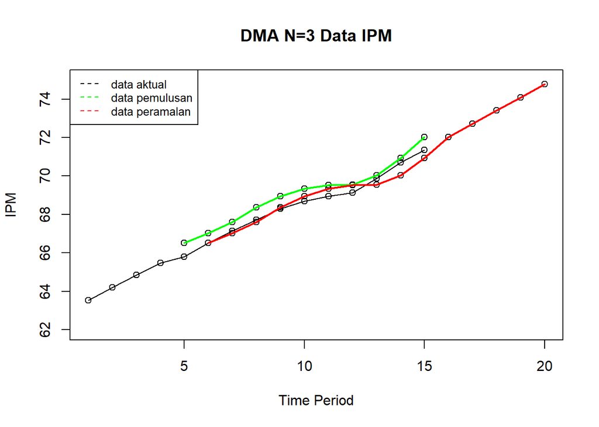

```r
# Plot deret waktu (time series) dari data aktual
ts.plot(dt.gab[,1],                      # kolom 1 = data aktual
        xlab = "Time Period",            # label sumbu x
        ylab = "IPM",                    # label sumbu y
        main = "DMA N=3 Data IPM",       # judul grafik
        ylim = c(62, 75))                # batas sumbu y (dari 62 sampai 75)

# Tambahkan titik-titik (points) untuk data aktual
points(dt.gab[,1])

# Tambahkan titik-titik untuk data pemulusan 2 (kolom 3 = dt.dma)
points(dt.gab[,3])

# Tambahkan titik-titik untuk data ramalan (kolom 6)
points(dt.gab[,6])

# Tambahkan garis untuk data pemulusan (warna hijau, tebal garis = 2)
lines(dt.gab[,3], col="green", lwd=2)

# Tambahkan garis untuk data ramalan (warna merah, tebal garis = 2)
lines(dt.gab[,6], col="red", lwd=2)

# Tambahkan legenda di pojok kiri atas
legend("topleft",
       c("data aktual", "data pemulusan", "data peramalan"),  # keterangan
       lty = 8,                                               # jenis garis
       col = c("black", "green", "red"),                      # warna sesuai garis
       cex = 0.8)                                             # ukuran teks
```

Selanjutnya akan dilihat keakuratan dari metode DMA

```r
# Menghitung ukuran akurasi metode DMA (m = 3)

# 1. Hitung error (selisih data aktual dengan ramalan historis)
error.dma <- data.ts - dt.ramal[1:length(data.ts)]

# 2. Hitung Sum of Squared Errors (SSE)
SSE.dma <- sum(error.dma[6:length(data.ts)]^2)

# 3. Hitung Mean Squared Error (MSE)
MSE.dma <- mean(error.dma[6:length(data.ts)]^2)

# 4. Hitung Mean Absolute Percentage Error (MAPE)
MAPE.dma <- mean(abs((error.dma[6:length(data.ts)] / data.ts[6:length(data.ts)]) * 100))

# 5. Gabungkan hasil ke dalam matriks ringkasan
akurasi.dma <- matrix(c(SSE.dma, MSE.dma, MAPE.dma))

# 6. Tambahkan nama baris dan kolom
row.names(akurasi.dma) <- c("SSE", "MSE", "MAPE")
colnames(akurasi.dma) <- c("Akurasi m = 3")

# 7. Tampilkan hasil akurasi
akurasi.dma
```

```
##      Akurasi m = 3
## SSE      1.1432383
## MSE      0.1143238
## MAPE     0.3955999
```

Selanjutnya akan digunakan metode Double Exponential Smoothing dengan cara sebagai berikut.

Pertama akan data akan dibagi menjadi data training dan data testing.

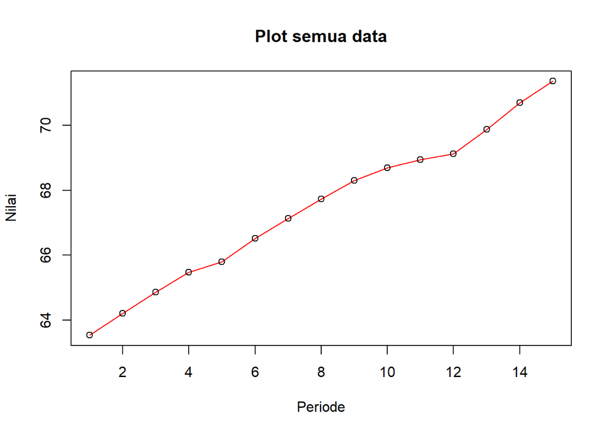

```r
  # 1. Membagi data menjadi training dan testing
training <- datas[1:11, 2]   # ambil 11 observasi pertama (kolom ke-2 = variabel target)
testing  <- datas[12:15, 2]  # ambil observasi ke-12 dan ke-15 sebagai data uji

# 2. Membuat objek time series
training.ts <- ts(training)        # data latih dalam bentuk time series
testing.ts  <- ts(testing, start=12) # data uji sebagai time series, dimulai dari periode ke-12

# 3. Eksplorasi data (visualisasi seluruh data asli)
plot(data.ts,
     col = "red",                  # warna merah untuk garis data
     main = "Plot semua data",     # judul grafik
     xlab = "Periode",             # label sumbu x
     ylab = "Nilai")               # label sumbu y
points(data.ts)                    # tambahkan titik di setiap observasi
```

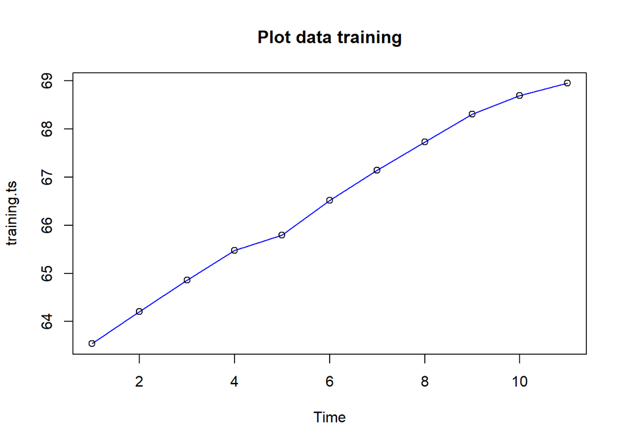

```r
plot(training.ts, col="blue",main="Plot data training")
points(training.ts)
```

Selanjutnya akan dilakukan pemulusan dengan DES, kali ini langsung dicari lambda dan gamma optimum sebagai berikut. Nilai lambda dan gamma optimum dapat dilihat pada smoothing parameters alpha untuk nilai lambda dan beta untuk nilai gamma.

```r
#Lamda dan gamma optimum
des.opt<- HoltWinters(training.ts, gamma = FALSE)
des.opt
```

```
## Holt-Winters exponential smoothing with trend and without seasonal component.
##
## Call:
## HoltWinters(x = training.ts, gamma = FALSE)
##
## Smoothing parameters:
##  alpha: 1
##  beta : 0.4249229
##  gamma: FALSE
##
## Coefficients:
##         [,1]
## a 68.9500000
## b  0.3988932
```

```r
# Membuat model Holt-Winters pada data training
# gamma = FALSE → model tanpa musiman (Holt’s Linear Trend / double exponential smoothing)
des.opt <- HoltWinters(training.ts, gamma = FALSE)

# Menampilkan hasil model (nilai alpha, beta, level, dan trend yang diperkirakan)
des.opt
```

```
## Holt-Winters exponential smoothing with trend and without seasonal component.
##
## Call:
## HoltWinters(x = training.ts, gamma = FALSE)
##
## Smoothing parameters:
##  alpha: 1
##  beta : 0.4249229
##  gamma: FALSE
##
## Coefficients:
##         [,1]
## a 68.9500000
## b  0.3988932
```

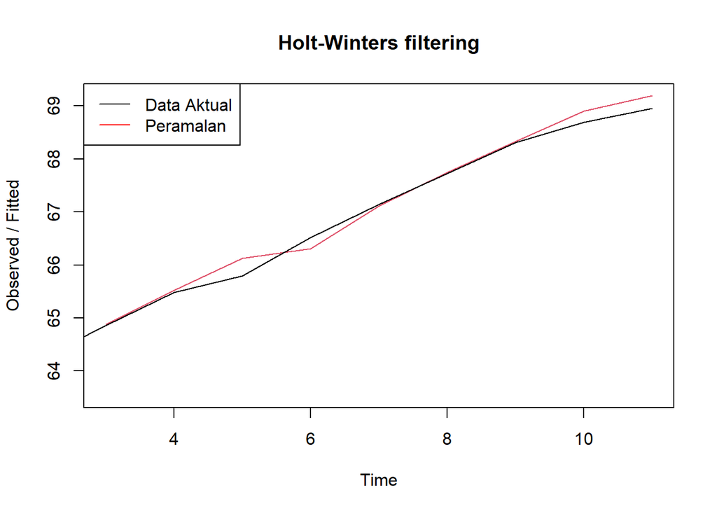

```r
# Membuat plot hasil pemodelan Holt-Winters
# Garis hitam = data aktual (training), garis merah = hasil pemulusan model
plot(des.opt)

# Menambahkan legenda di pojok kiri atas
# Hitam = data aktual, Merah = hasil peramalan (fit values)
legend("topleft", c("Data Aktual", "Peramalan"),
       col = c("black", "red"),
       lty = c(1, 1))
```

```r
# Membuat ramalan menggunakan model Holt-Winters hasil training
# h = 5 → meramalkan 5 periode ke depan
ramalandesopt <- forecast(des.opt, h = 5)

# Menampilkan hasil ramalan
# Output biasanya berisi: nilai ramalan (Point Forecast),
# serta interval prediksi (Lo 80/95 dan Hi 80/95)
ramalandesopt
```

```
##    Point Forecast    Lo 80    Hi 80    Lo 95    Hi 95
## 12       69.34889 69.14044 69.55734 69.03010 69.66769
## 13       69.74779 69.38491 70.11066 69.19282 70.30275
## 14       70.14668 69.61718 70.67617 69.33689 70.95647
## 15       70.54557 69.83479 71.25635 69.45853 71.63262
## 16       70.94447 70.03788 71.85105 69.55796 72.33097
```

Selanjutnya akan dicari akurasi dari metode DES.

```r
# Mengambil nilai SSE (Sum of Squared Errors) dari model Holt-Winters pada data training
ssedes.train <- des.opt$SSE

# Menghitung MSE (Mean Squared Error) pada data training
# Caranya: SSE dibagi jumlah data training
msedes.train <- ssedes.train / length(training.ts)

# Mengambil nilai residual (selisih antara data aktual dan hasil model)
# Residual ini bisa dipakai untuk cek pola kesalahan model
sisaandes <- ramalandesopt$residuals

# Menampilkan beberapa nilai awal residual untuk dicek
head(sisaandes)
```

```
## Time Series:
## Start = 1
## End = 6
## Frequency = 1
## [1]          NA          NA -0.02000000 -0.04150154 -0.32386659  0.21375174
```

```r
# Menghitung nilai MAPE (Mean Absolute Percentage Error) pada data training
# Rumus: rata-rata dari |(aktual - ramalan)/aktual| * 100
# Indeks mulai dari 3 → menghindari error pada awal data yang kurang stabil
mapedes.train <- sum(abs(sisaandes[3:length(training.ts)] / training.ts[3:length(training.ts)]) * 100) / length(training.ts)

# Membuat matriks berisi nilai akurasi (SSE, MSE, MAPE)
akurasides.opt <- matrix(c(ssedes.train, msedes.train, mapedes.train))

# Memberi nama baris matriks sesuai metrik akurasi
row.names(akurasides.opt) <- c("SSE", "MSE", "MAPE")

# Memberi nama kolom matriks sebagai keterangan model yang digunakan
colnames(akurasides.opt) <- c("Akurasi lamda dan gamma optimum")

# Menampilkan matriks akurasi
akurasides.opt
```

```
##      Akurasi lamda dan gamma optimum
## SSE                       0.25688231
## MSE                       0.02335294
## MAPE                      0.15031226
```

```r
#Akurasi data testing
selisihdesopt<-ramalandesopt$mean-testing.ts
selisihdesopt
```

```
## Time Series:
## Start = 12
## End = 15
## Frequency = 1
## [1]  0.2188932 -0.1222137 -0.5533205 -0.8144274
```

```r
# Menghitung SSE (Sum of Squared Errors) pada data testing
# selisihdesopt = perbedaan antara data aktual (testing) dan hasil ramalan
SSEtestingdesopt <- sum(selisihdesopt^2)

# Menghitung MSE (Mean Squared Error) pada data testing
# Caranya SSE dibagi jumlah data testing
SSEtestingdesopt <- SSEtestingdesopt / length(testing.ts)

# Menghitung MAPE (Mean Absolute Percentage Error) pada data testing
# Rumus: rata-rata dari |(aktual - ramalan)/aktual| * 100
MAPEtestingdesopt <- sum(abs(selisihdesopt / testing.ts) * 100) / length(testing.ts)

# Membuat matriks berisi nilai akurasi (SSE, MSE, MAPE) untuk data testing
akurasiDesTesting <- matrix(c(SSEtestingdesopt, SSEtestingdesopt, MAPEtestingdesopt))

# Memberi nama baris matriks sesuai metrik akurasi
row.names(akurasiDesTesting) <- c("SSE", "MSE", "MAPE")

# Memberi nama kolom matriks sesuai model yang digunakan
colnames(akurasiDesTesting) <- c("Akurasi lamda dan gamma optimum")

# Menampilkan matriks akurasi pada data testing
akurasiDesTesting
```

```
##      Akurasi lamda dan gamma optimum
## SSE                        0.2580765
## MSE                        0.2580765
## MAPE                       0.6038703
```

Setelah didapatkan nilai akurasi untuk metode DMA dan DES, selanjutnya akan dibandingkan keakuratan antar metode keduanya.

```r
# Menggabungkan hasil akurasi DMA dan akurasi Holt-Winters (des.opt) ke dalam satu tabel
# Fungsi cbind() → menggabungkan secara kolom
cbind(akurasi.dma, akurasides.opt)
```

```
##      Akurasi m = 3 Akurasi lamda dan gamma optimum
## SSE      1.1432383                      0.25688231
## MSE      0.1143238                      0.02335294
## MAPE     0.3955999                      0.15031226
```

Berdasarkan perbandingan akurasi tersebut, terlihat nilai SSE, MSE, dan MAPE metode DES lebih kecil dibandingkan dengan metode DMA. Oleh karena itu, metode peramalan dan pemulusan yang terbaik antara keduanya adalah dengan metode DES.

Setelah melakukan peramalan, data yang telah dimasukkan kemudian dieksplorasi. Eksplorasi pertama yang dilakukan adalah dengan menggunakan scatter plot.

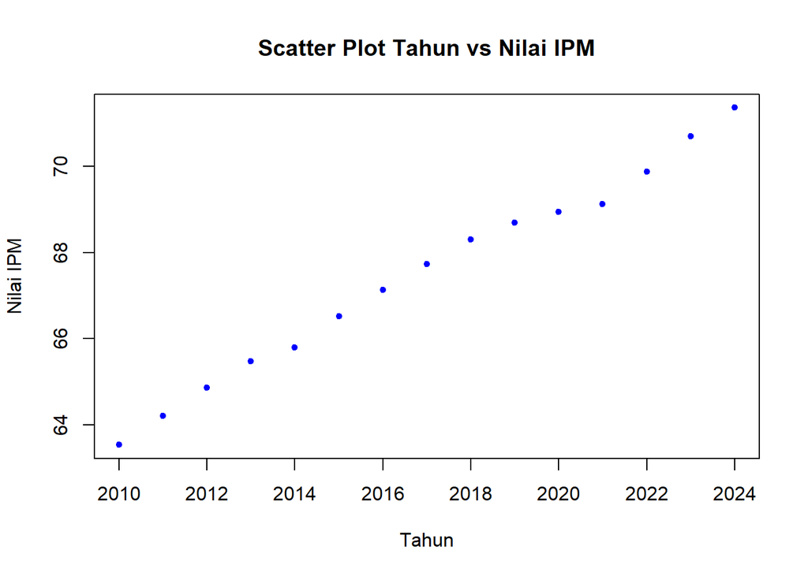

```r
#Eksplorasi Data
#Pembuatan Scatter Plot
plot(tahun,ipm, pch = 20, col = "blue",
     main = "Scatter Plot Tahun vs Nilai IPM",
     xlab = "Tahun",
     ylab = "Nilai IPM")
```

```r
#Menampilkan Nilai Korelasi
cor(tahun,ipm)
```

```
## [1] 0.9959607
```

Berdasarkan scatter plot di atas, terlihat adanya hubungan / korelasi positif antara peubah tahun dengan nilai IPM, terlihat titik-titik pada plot yang naik ke arah kanan atas. Hal tersebut juga diperkuat dengan hasil perhitungan aplikasi R di mana didapatkan nilai korelasi sebesar 0.9959607.

Setalah mengetahui adanya hubungan antar dua peubah, maka model regresi dapat ditentukan.

# Regresi

```r
#Pembuatan Model Regresi
#model regresi
model<- lm(ipm~tahun, data = datas)
summary(model)
```

```
##
## Call:
## lm(formula = ipm ~ tahun, data = datas)
##
## Residuals:
##      Min       1Q   Median       3Q      Max
## -0.47443 -0.11159  0.03636  0.15577  0.29439
##
## Coefficients:
##               Estimate Std. Error t value Pr(>|t|)
## (Intercept) -1.001e+03  2.671e+01  -37.47 1.25e-14 ***
## tahun        5.296e-01  1.324e-02   39.99 5.37e-15 ***
## ---
## Signif. codes:  0 '***' 0.001 '**' 0.01 '*' 0.05 '.' 0.1 ' ' 1
##
## Residual standard error: 0.2216 on 13 degrees of freedom
## Multiple R-squared:  0.9919, Adjusted R-squared:  0.9913
## F-statistic:  1599 on 1 and 13 DF,  p-value: 5.372e-15
```

Model yang dihasilkan adalah
$$\hat{y} =
-1001 + 0.5296 \times \text{tahun}$$
Berdasarkan ringkasan model dapat diketahui bahwa hasil uji F memiliki p-value < α (5%). Artinya, minimal terdapat satu variabel yang berpengaruh nyata terhadap model. Hasil uji-t parsial kedua parameter regresi, yaitu intersep dan koefisien regresi juga menunjukkan hal yang sama, yaitu memiliki p-value < α (5%) sehingga nyata dalam taraf 5%. Selanjutnya dapat dilihat juga nilai
$$R^2 = 0.9919$$
. Artinya, sebesar 99.19% keragaman nilai IPM dapat dijelaskan oleh peubah tahun. Hasil ini menunjukkan hasil yang bagus, seolah mendapatkan hasil terbaik. Namun, kita perlu melakukan uji terhadap sisaannya seperti berikut ini.

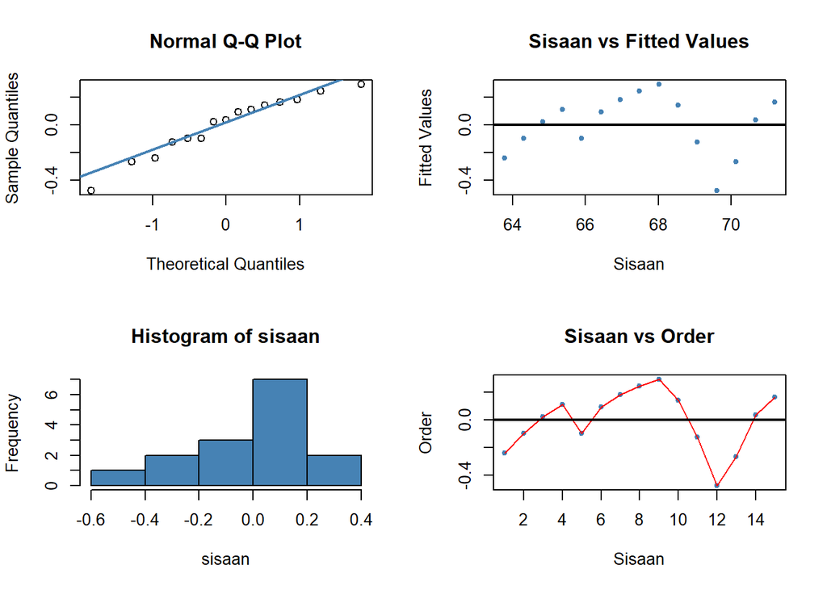

```r
#sisaan dan fitted value
sisaan<- residuals(model)
fitValue<- predict(model)

#Diagnostik dengan eksploratif
par(mfrow = c(2,2))
qqnorm(sisaan)
qqline(sisaan, col = "steelblue", lwd = 2)
plot(fitValue, sisaan, col = "steelblue", pch = 20, xlab = "Sisaan", ylab = "Fitted Values", main = "Sisaan vs Fitted Values")
abline(a = 0, b = 0, lwd = 2)
hist(sisaan, col = "steelblue")
plot(seq(1,15,1), sisaan, col = "steelblue", pch = 20, xlab = "Sisaan", ylab = "Order", main = "Sisaan vs Order")
lines(seq(1,15,1), sisaan, col = "red")
abline(a = 0, b = 0, lwd = 2)
```

Dua plot di samping kiri digunakan untuk melihat apakah sisaan menyebar normal. Normal Q-Q Plot di atas menunjukkan bahwa sisaan cenderung menyebar normal, tetapi histogram dari sisaan tidak menunjukkan demikian. Selanjutnya, dua plot di samping kanan digunakan untuk melihat autokorelasi. Plot Sisaan vs Fitted Value dan Plot Sisaan vs Order menunjukkan adanya pola pada sisaan. Untuk lebih lanjut akan digunakan uji formal melihat normalitas sisaan dan plot ACF dan PACF untuk melihat apakah ada autokorelasi atau tidak.

```r
#Melihat Sisaan Menyebar Normal/Tidak
#H0: sisaan mengikuti sebaran normal
#H1: sisaan tidak mengikuti sebaran normal
shapiro.test(sisaan)
```

```
##
##  Shapiro-Wilk normality test
##
## data:  sisaan
## W = 0.94943, p-value = 0.5156
```

```r
ks.test(sisaan, "pnorm", mean=mean(sisaan), sd=sd(sisaan))
```

```
##
##  Exact one-sample Kolmogorov-Smirnov test
##
## data:  sisaan
## D = 0.1411, p-value = 0.8866
## alternative hypothesis: two-sided
```

Berdasarkan uji formal Saphiro-Wilk dan Kolmogorov-Smirnov didapatkan nilai p-value > α (5%). Artinya, cukup bukti untuk menyatakan sisaan berdistribusi normal.

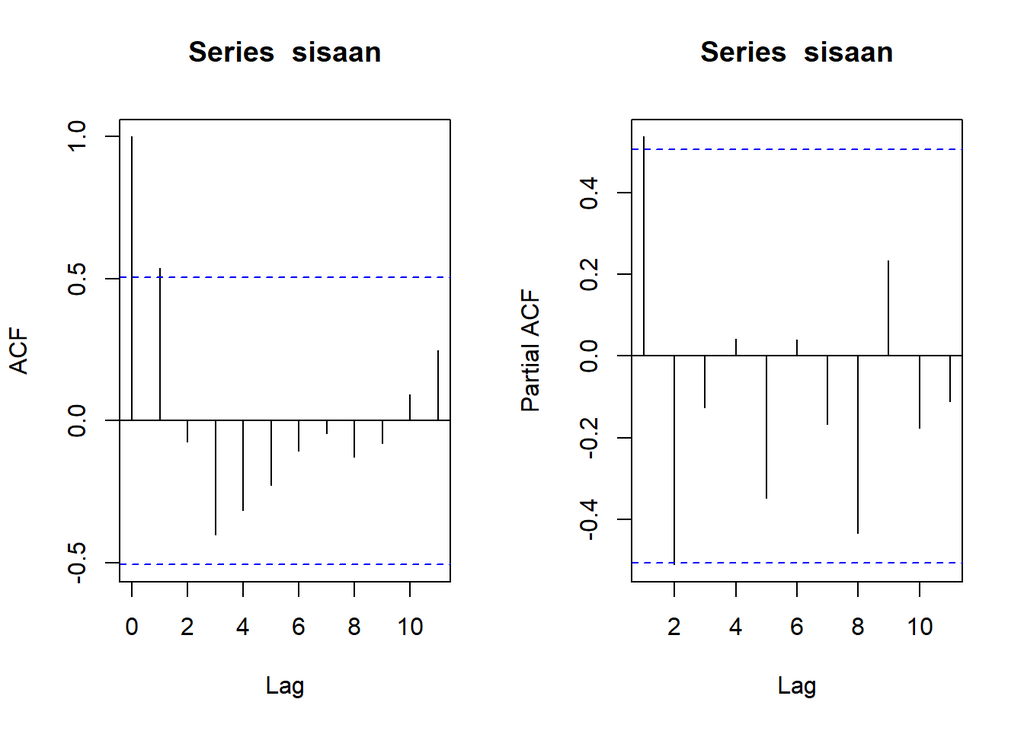

```r
#ACF dan PACF identifikasi autokorelasi
par(mfrow = c(1,2))
acf(sisaan)
pacf(sisaan)
```

```r
#Deteksi autokorelasi dengan uji-Durbin Watson
#H0: tidak ada autokorelasi
#H1: ada autokorelasi
dwtest(model)
```

```
##
##  Durbin-Watson test
##
## data:  model
## DW = 0.79227, p-value = 0.001025
## alternative hypothesis: true autocorrelation is greater than 0
```

Nilai p-value < 0.05 dapat disimpulkan bahwa tolak H0, cukup bukti mengatakan adanya autokorelasi. Oleh karena itu, diperlukan penangan autokorelasi. Penanganan yang akan digunakan menggunakan dua metode, yaitu Cochrane-Orcutt dan Hildret-Lu.

# Penanganan Autokorelasi

## Metode Cochrane-Orcutt

Penanganan metode Cochrane-Orcutt dapat dilakukan dengan bantuan packages Orcutt pada aplikasi R maupun secara manual. Berikut ini ditampilkan cara menggunakan bantuan library packages Orcutt.

```r
#Penanganan Autokorelasi Cochrane-Orcutt
modelCO<-cochrane.orcutt(model)
modelCO
```

```
## Cochrane-orcutt estimation for first order autocorrelation
##
## Call:
## lm(formula = ipm ~ tahun, data = datas)
##
##  number of interaction: 9
##  rho 0.558556
##
## Durbin-Watson statistic
## (original):    0.79227 , p-value: 1.025e-03
## (transformed): 1.25641 , p-value: 3.22e-02
##
##  coefficients:
## (Intercept)       tahun
## -978.725428    0.518733
```

Hasil keluaran model setelah dilakukan penanganan adalah sebagai berikut.
$$\hat{y} = -978.7254 + 0.5187
\times \text{tahun}$$
Hasil juga menunjukkan bahwa nilai p-value meningkat menjadi 0.0322. Nilai p-value < 0.05, artinya cukup bukti untuk menyatakan bahwa sisaan terdapat autokorelasi pada taraf nyata 5%. Untuk nilai ρ̂ optimum yang digunakan adalah 0.558556 . Nilai tersebut dapat diketahui dengan syntax berikut.

```r
#Rho optimum
rho<- modelCO$rho
rho
```

```
## [1] 0.5585558
```

```r
ipm
```

```
##  [1] 63.54 64.21 64.86 65.48 65.80 66.52 67.14 67.73 68.31 68.69 68.95 69.13
## [13] 69.87 70.70 71.36
```

```r
ipm[-1]
```

```
##  [1] 64.21 64.86 65.48 65.80 66.52 67.14 67.73 68.31 68.69 68.95 69.13 69.87
## [13] 70.70 71.36
```

```r
#Transformasi Manual
ipm.trans<- ipm[-1]-ipm[-15]*rho
tahun.trans<- tahun[-1]-tahun[-15]*rho
modelCOmanual<- lm(ipm.trans~tahun.trans)
summary(modelCOmanual)
```

```
##
## Call:
## lm(formula = ipm.trans ~ tahun.trans)
##
## Residuals:
##      Min       1Q   Median       3Q      Max
## -0.41161 -0.03209  0.04084  0.11445  0.18653
##
## Coefficients:
##               Estimate Std. Error t value Pr(>|t|)
## (Intercept) -432.05265   23.67435  -18.25 4.05e-10 ***
## tahun.trans    0.51873    0.02657   19.53 1.84e-10 ***
## ---
## Signif. codes:  0 '***' 0.001 '**' 0.01 '*' 0.05 '.' 0.1 ' ' 1
##
## Residual standard error: 0.1769 on 12 degrees of freedom
## Multiple R-squared:  0.9695, Adjusted R-squared:  0.9669
## F-statistic: 381.3 on 1 and 12 DF,  p-value: 1.844e-10
```

```r
#Mencari Penduga Koefisien Regresi setelah Transformasi ke Persamaan Awal
b0bintang <- modelCOmanual$coefficients[-2]
b0 <- b0bintang/(1-rho)
b1 <- modelCOmanual$coefficients[-1]
b0
```

```
## (Intercept)
##   -978.7254
```

```r
b1
```

```
## tahun.trans
##   0.5187329
```

Hasil perhitungan koefisien regresi tersebut akan menghasilkan hasil yang sama dengan model yang dihasilkan menggunakan packages.

## Metode Hildreth-Lu

Penanganan kedua adalah menggunakan metode Hildreth-Lu. Metode ini akan mencari nilai SSE terkecil dan dapat dicari secara manual maupun menggunakan packages. Jika menggunakan packages, gunakan library packages HORM.

```r
#Penanganan Autokorelasi Hildreth lu
# Hildreth-Lu
hildreth.lu.func<- function(r, model){
  x <- model.matrix(model)[,-1]
  y <- model.response(model.frame(model))
  n <- length(y)
  t <- 2:n
  y <- y[t]-r*y[t-1]
  x <- x[t]-r*x[t-1]

  return(lm(y~x))
}

#Pencarian rho yang meminimumkan SSE
r <- c(seq(0.1,0.9, by= 0.1))
tab <- data.frame("rho" = r, "SSE" = sapply(r, function(i){deviance(hildreth.lu.func(i, model))}))
round(tab, 4)
```

```
##   rho    SSE
## 1 0.1 0.5020
## 2 0.2 0.4528
## 3 0.3 0.4157
## 4 0.4 0.3906
## 5 0.5 0.3775
## 6 0.6 0.3765
## 7 0.7 0.3875
## 8 0.8 0.4105
## 9 0.9 0.4456
```

Pertama-tama akan dicari di mana kira-kira ρ yang menghasilkan SSE minimum. Pada hasil di atas terlihat ρ minimum ketika 0.6. Namun, hasil tersebut masih kurang teliti sehingga akan dicari kembali ρ yang lebih optimum dengan ketelitian yang lebih.

```r
#Rho optimal di sekitar 0.4
rOpt <- seq(0.5,0.6, by= 0.001)
tabOpt <- data.frame("rho" = rOpt, "SSE" = sapply(rOpt, function(i){deviance(hildreth.lu.func(i, model))}))
head(tabOpt[order(tabOpt$SSE),])
```

```
##      rho       SSE
## 60 0.559 0.3754444
## 59 0.558 0.3754445
## 61 0.560 0.3754456
## 58 0.557 0.3754458
## 62 0.561 0.3754479
## 57 0.556 0.3754483
```

[figure not shown]

```r
#Grafik SSE optimum
par(mfrow = c(1,1))
plot(tab$SSE ~ tab$rho , type = "l", xlab = "Rho", ylab = "SSE")
abline(v = tabOpt[tabOpt$SSE==min(tabOpt$SSE),"rho"], lty = 2, col="red",lwd=2)
text(x=0.559, y=0.3754444, labels = "rho=0.341", cex = 0.8)
```

Perhitungan yang dilakukan aplikasi R menunjukkan bahwa nilai ρ optimum, yaitu saat SSE terkecil terdapat pada nilai ρ = 0.559 . Hal tersebut juga ditunjukkan pada plot. Selanjutnya, model dapat didapatkan dengan mengevaluasi nilai ρ ke dalam fungsi hildreth.lu.func, serta dilanjutkan dengan pengujian autokorelasi dengan uji Durbin-Watson. Namun, setelah pengecekan tersebut tidak lupa koefisien regresi tersebut digunakan untuk transformasi balik. Persamaan hasil transformasi itulah yang menjadi persamaan sesungguhnya.

```r
#Model terbaik
modelHL <- hildreth.lu.func(0.559, model)
summary(modelHL)
```

```
##
## Call:
## lm(formula = y ~ x)
##
## Residuals:
##      Min       1Q   Median       3Q      Max
## -0.41157 -0.03217  0.04086  0.11440  0.18663
##
## Coefficients:
##               Estimate Std. Error t value Pr(>|t|)
## (Intercept) -431.61305   23.67438  -18.23 4.10e-10 ***
## x              0.51873    0.02659   19.51 1.87e-10 ***
## ---
## Signif. codes:  0 '***' 0.001 '**' 0.01 '*' 0.05 '.' 0.1 ' ' 1
##
## Residual standard error: 0.1769 on 12 degrees of freedom
## Multiple R-squared:  0.9694, Adjusted R-squared:  0.9669
## F-statistic: 380.5 on 1 and 12 DF,  p-value: 1.866e-10
```

```r
#Transformasi Balik
cat("y = ", coef(modelHL)[1]/(1-0.559), "+", coef(modelHL)[2],"x", sep = "")
```

```
## y = -978.7144+0.5187275x
```

Setelah dilakukan tranformasi balik, didapatkan model dengan metode Hildreth-Lu sebagai berikut.
$$y = -978.7144 + 0.5187275 \, x$$

```r
#Deteksi autokorelasi
dwtest(modelHL)
```

```
##
##  Durbin-Watson test
##
## data:  modelHL
## DW = 1.2567, p-value = 0.03225
## alternative hypothesis: true autocorrelation is greater than 0
```

Terakhir, akan dibandingkan nilai SSE dari ketiga metode (metode awal, metode Cochrane-Orcutt, dan Hildreth-Lu).

```r
#Perbandingan
sseModelawal <- anova(model)$`Sum Sq`[-1]
sseModelCO <- anova(modelCOmanual)$`Sum Sq`[-1]
sseModelHL <- anova(modelHL)$`Sum Sq`[-1]
mseModelawal <- sseModelawal/length(ipm)
mseModelCO <- sseModelCO/length(ipm)
mseModelHL <- sseModelHL/length(ipm)
akurasi <- matrix(c(sseModelawal,sseModelCO,sseModelHL,
                    mseModelawal,mseModelCO,mseModelHL),nrow=2,ncol=3,byrow = T)
colnames(akurasi) <- c("Model Awal", "Model Cochrane-Orcutt", "Model Hildreth-Lu")
row.names(akurasi) <- c("SSE","MSE")
akurasi
```

```
##     Model Awal Model Cochrane-Orcutt Model Hildreth-Lu
## SSE 0.63831679            0.37544433        0.37544444
## MSE 0.04255445            0.02502962        0.02502963
```

Berdasarkan hasil tersebut dapat diketahui bahwa penanganan autokorelasi dengan metode Cochrane-Orcutt dan Hildreth-Lu menghasilkan SSE dan MSE yang hampir sama, yaitu 0.37544433 dan 0.02502962 untuk Cochrane-Orcutt, serta 0.37544444 dan 0.02502963 untuk Hildreth-Lu. Nilai ini lebih baik dibandingkan model awal sebelum penanganan autokorelasi, yang memiliki SSE 0.63831679 dan MSE 0.04255445.

# Simpulan

Autokorelasi yang terdapat pada data IPM terjadi akibat adanya korelasi di antara unsur penyusunnya. Indikator IPM yang erat hubungannya dengan perekonomian sangat rawan menjadi penyebab autokorelasi. Adanya autokorelasi menyebabkan model regresi kurang baik karena akan meningkatkan galatnya. Autokorelasi dapat dideteksi secara eksploratif melalui plot residual, ACF, dan PACF, serta dengan uji formal Durbin-Watson. Meskipun telah dilakukan penanganan autokorelasi dengan metode Cochrane-Orcutt dan Hildreth-Lu, uji Durbin-Watson menunjukkan bahwa autokorelasi residual masih signifikan, sehingga H₀ ditolak. Hal ini mengindikasikan bahwa meskipun kedua metode menurunkan SSE dan MSE dibanding model awal, residual belum sepenuhnya bebas dari autokorelasi, sehingga perlu diperhatikan dalam interpretasi model dan prediksi.